# Extreme weather events in the Netherlands

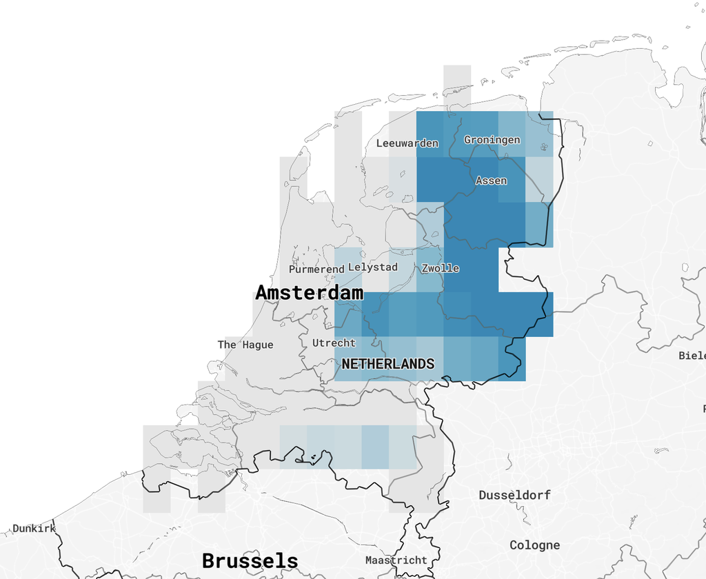

The Netherlands, Min T recorded in August 2026

We count the **country-months** above 1: one country in extreme heat for one month = 1. With 45 countries and 12 months, a year has 540 country-months for each component.

**Each hazard has its own story** One small chart per component (*small multiples*): every bar is the share of country-months above 1 in one year, the dashed line is the average of 1981–2010.

[figure not shown]

💬 Since 2011, months of extreme heat have been **more than 3 times** as frequent as in 1981–2010, and fire-weather extremes almost 3 times, while cold extremes and hail have become rarer. Precipitation, wind and drought change less, and less regularly: trends in these hazards are harder to detect than in temperature.

Now let’s look at the same hazards from another angle: **when in the year** do they strike?

**Record of extremes events** A *rose* for each hazard and period, inspired by Florence Nightingale’s diagrams (1858). **How to read it:** * every petal is a **calendar month**: January at the top, then clockwise (April on the right, July at the bottom, October on the left); * the **area** of a petal, not its length, is proportional to the share of country-months that were extreme in that month, as in Nightingale’s roses; * inside each petal the classes go **from the centre outwards**: 1–2 (the lightest shade), 2–3, above 3 (the darkest); * top row: 1981–2010; bottom row: since 2011.

Remember: an E3CI “heat extreme” in January is an unusually **warm January**, not a 40 °C day.

[figure not shown]

From here on, every chart looks at **one component** (or two) or at **one place**: in this guided tour we chose extreme heat, July and Italy, and the settings at the top of each cell can show any other.

**2.1 One month, all countries** Extreme heat in **July**: every row is a country, every cell a year. On the right, how many extreme Julys each country had since 1981: the countries with the most are at the top.

*Why July?* It is the heart of summer, when heat extremes hit people the hardest. But the E3CI compares every July only with the Julys of 1981–2010, so any other month can be read in the same way: in the second part of the workshop you can choose it (`MONTH = 0` shows the strongest month of each year).

[figure not shown]

First we load the country shapes (Natural Earth, ~3 MB), then we draw one small map per year: *small multiples* let the eye compare 46 Julys at once.

[figure not shown]

Inspired by Ed Hawkins’ *warming stripes*: one row per component, one cell per year.

[figure not shown]

Now one component only: extreme heat. Every bar is one month, coloured by E3CI class; the dots mark the three most intense months on record, with their value.

[figure not shown]

The same months, seen through their **records**. A record is a month with a higher E3CI than every month before it in the same country, since January 1981. In a climate that does not change, **records become rarer and rarer**: after 10 years the chance that a month beats all the previous ones is about 1 in 120; after 40 years, about 1 in 480. That’s why we start counting in **1991**: in the first years almost every month is a record, because there is hardly any history to beat.

📐 **How many records should we expect?** In a stable climate each of the first *n* months has the same chance of being the highest, so month *n* sets a record with probability **1/n**. Adding up 1/n over the months since 1991 gives the number of records we would expect if nothing were changing. It is a reference, not an exact forecast: anomalies persist from one month to the next, so records can come in clusters.

[figure not shown]

The same data as a heatmap: rows are months, columns are years. Top: extreme months per year. Right: how often each calendar month was extreme, then (grey) and now (colour).

[figure not shown]

## A real event

Many events hit only one region: here we use the **regional data** loaded in the setup. In May 2023 two waves of torrential rain flooded Romagna: was it the most intense month on record in Emilia-Romagna? How does it compare with the rest of Europe? The first cell lists other famous events: in the second part of the workshop you can choose one of them.

[figure not shown]